# Global Language Diversity on Wikipedia

A table showing the relationship between language speaker populations and Wikipedia article counts.

Author

Carwil Bjork-James

Published

August 1, 2026

# Languages and Wikipedia Articles

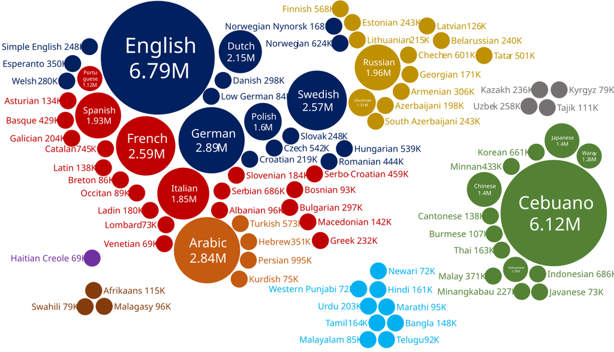

The largest Wikipedia editions by number of articles, as visualized by [Arief Azazie Zain](https://commons.wikimedia.org/wiki/User:Arief_Azazie_Zain) in 2024.

## Top 250 Languages by Number of Speakers

Note that the language rank is computed for this table and therefore includes a handful of spoken languages or dialects not included in LinguaMeta (i.e., Aromanian, Banyamasan, Võro, Dutch Low Saxon, and Tarantino). No attempt has been made to add all comporable languages missing from LinguaMeta without an edition of Wikipedia.

Background shading: **blue** = speaker population; **green/gold** = Wikipedia article count.

| Language | Language Description | Speakers (L1 est.) | Wikipedia Articles | Wikipedia Edition |
| --- | --- | --- | --- | --- |
| 1. Chinese<br> 中文 | NA | 1,288,700,000 | 1,546,875 | <a href="https://zh.wikipedia.org/">Chinese Wikipedia</a> <br><em>Traditional Chinese: 中文維基百科, Simplified Chinese: 中文维基百科<br>(pinyin: Zhōngwén wéijī bǎikē)</em> |
| 2. English<br> <i>English</i> | West Germanic language | 1,267,445,366 | 7,217,810 | <a href="https://en.wikipedia.org/">English Wikipedia</a> <br><em>English Wikipedia</em> |
| 3. Mandarin Chinese<br> 普通话 | major branch of Chinese spoken across most of northern and southwestern China | 990,000,000 | 1,546,875 | In <a href="https://zh.wikipedia.org/">Chinese Wikipedia</a> <br><em>Traditional Chinese: 中文維基百科, Simplified Chinese: 中文维基百科<br>(pinyin: Zhōngwén wéijī bǎikē)</em> |
| 4. Hindi<br> हिन्दी | Indo-Aryan language spoken chiefly in North India | 544,000,000 | 170,698 | <a href="https://hi.wikipedia.org/">Hindi Wikipedia</a> <br><em>हिन्दी विकिपीडिया<br>(Hindī vikipīḍiyā)</em> |
| 5. Spanish<br> <i>español</i> | Romanic language originating in the Iberian Peninsula | 468,360,000 | 2,128,879 | <a href="https://es.wikipedia.org/">Spanish Wikipedia</a> <br><em>Wikipedia en español</em> |
| 6. Arabic<br> العربية | NA | 346,277,000 | 1,326,304 | <a href="https://ar.wikipedia.org/">Arabic Wikipedia</a> <br><em>ويكيبيديا العربية<br>(Wīkībīdiyā al-ʿarabiyya)</em> |
| 7. Urdu<br> اردو | Indo-Aryan language spoken in South Asia | 288,000,000 | 668,499 | <a href="https://ur.wikipedia.org/">Urdu Wikipedia</a> <br><em>اردو ویکیپیڈیا<br>(Urdū vikipīḍiyā)</em> |
| 8. Bengali<br> বাংলা | Indo-Aryan language mostly spoken in Bangladesh and India | 266,000,000 | 189,887 | <a href="https://bn.wikipedia.org/">Bengali Wikipedia</a> <br><em>বাংলা উইকিপিডিয়া<br>(Bāṅlā uikipiḍiẏa)</em> |
| 9. Portuguese<br> <i>português</i> | Romance language | 225,751,001 | 1,179,249 | <a href="https://pt.wikipedia.org/">Portuguese Wikipedia</a> <br><em>Wikipédia em português</em> |
| 10. French<br> <i>français</i> | Romance language | 203,194,940 | 2,772,415 | <a href="https://fr.wikipedia.org/">French Wikipedia</a> <br><em>Wikipédia en français</em> |

[output cut: 240 more lines]

## Top 250 at a Glance

Languages ranked left-to-right, top-to-bottom by estimated L1 speaker population. Background color reflects Wikipedia article count: **slate** = no Wikipedia; **teal/green** = small–medium edition; **amber** = largest editions (1M+ articles).

**Chinese**  
中文  
1.3B 1.5M

**English**  
English  
1.3B 7.2M

**Mandarin Chinese**  
普通话  
990.0M 1.5M

**Hindi**  
हिन्दी  
544.0M 171K

**Spanish**  
español  
468.4M 2.1M

**Arabic**  
العربية  
346.3M 1.3M

**Urdu**  
اردو  
288.0M 668K

**Bengali**  
বাংলা  
266.0M 190K

**Portuguese**  
português  
225.8M 1.2M

**French**  
français  
203.2M 2.8M

**Punjabi**  
پنجابی  
200.0M 60K

**Indonesian**  
Bahasa Indonesia  
171.0M 787K

**Swahili**  
Kiswahili  
171.0M 122K

**Russian**  
русский  
170.2M 2.1M

**Japanese**  
日本語  
119.0M 1.5M

**Western Panjabi**  
شاہ مُکھی  
113.0M 76K

**Telugu**  
తెలుగు  
95.0M 127K

**Lahnda**  
93.0M 76K

**Marathi**  
मराठी  
93.0M 102K

**German**  
Deutsch  
91.7M 3.1M

**Javanese**  
Basa Jawa  
91.0M 75K

**Vietnamese**  
Tiếng Việt  
85.0M 1.3M

**Wu Chinese**  
吳語  
84.0M 48K

**Persian**  
فارسی  
82.0M 1.1M

**Caribbean Javanese**  
82.0M 75K

**Tamil**  
தமிழ்  
81.5M 189K

**Yue Chinese**  
廣東話  
79.0M 151K

**Egyptian Arabic**  
اللغه المصريه الحديثه  
78.0M 1.3M

**Turkish**  
Türkçe  
76.3M 693K

**Korean**  
한국어  
75.0M 757K

**Filipino**  
Filipino  
66.0M 49K

**Italian**  
italiano  
65.3M 2.0M

**Jinyu Chinese**  
晋语  
63.0M 1.5M

**Gujarati**  
ગુજરાતી  
60.0M 31K

**Thai**  
ภาษาไทย  
55.0M 186K

**Pashto**  
پښتو  
53.0M 21K

**Kannada**  
ಕನ್ನಡ  
49.0M 35K

**Nigerian Pidgin**  
Naija  
45.0M 2K

**Malayalam**  
മലയാളം  
42.0M 88K

**Min Nan Chinese**  
Min Nan  
42.0M 434K

**Oromo**  
Afaan Oromoo  
42.0M 2K

**Odia (Oriya)**  
ଓଡ଼ିଆ  
42.0M 21K

**Xiang Chinese**  
湘語  
40.0M 1.5M

**Sindhi**  
سنڌي  
38.4M 22K

**Sudanese Arabic**  
لهجة سودانية  
37.0M 1.3M

**Fulah**  
Fulfulde  
37.0M 21K

**Polish**  
polski  
37.0M 1.7M

**Amharic**  
አማርኛ  
36.0M 16K

**Algerian Arabic**  
الدارجة الجزائرية  
36.0M 1.3M

**Myanmar (Burmese)**  
မြန်မာ  
36.0M 112K

**Odia**  
35.0M 21K

**Malay**  
Bahasa Melayu  
34.4M 440K

**Bhojpuri**  
भोजपुरी  
33.5M 9K

**Tagalog**  
Filipino  
33.0M 49K

**Hakka Chinese**  
客家話  
32.0M 10K

**Sundanese**  
Basa Sunda  
32.0M 63K

**Moroccan Arabic**  
الداريجة المغريبية  
31.0M 19K

**Azerbaijani**  
Azərbaycanca  
29.2M 216K

**Ukrainian**  
українська  
29.0M 1.4M

**Hausa**  
Hausa  
28.2M 107K

**Igbo**  
Igbo  
28.0M 48K

**Saraiki**  
سرائیکی  
28.0M 25K

**Northern Uzbek**  
28.0M 353K

**Yoruba**  
Èdè Yorùbá  
28.0M 39K

**Cebuano**  
Cebuano  
26.0M 6.1M

**Uzbek**  
o‘zbek  
26.0M 353K

**Saidi Arabic**  
صعيدى  
25.0M 1.3M

**Awadhi**  
अवधी  
25.0M 3K

**Antankarana Malagasy**  
25.0M 104K

**Dutch**  
Nederlands  
24.1M 2.2M

**South Azerbaijani**  
تۆرکجه  
24.0M 245K

**North Azerbaijani**  
24.0M 216K

**Gan Chinese**  
贛語  
24.0M 7K

**Malagasy**  
Malagasy  
24.0M 104K

**Marwari**  
मारवाड़ी  
22.0M —

**Romanian**  
română  
21.1M 546K

**Nepali**  
नेपाली  
20.4M 30K

**Maithili**  
मैथिली  
19.3M 14K

**Rajasthani**  
राजस्थानी  
19.3M —

**Serbo-Croatian**  
srpskohrvatski jezik  
19.0M 462K

## Additional Languages with Wikipedia Editions

These languages fall outside the top 250 by speaker population but have active Wikipedia editions. Global rank (by estimated L1 speakers) shown where available.

| Language | Language Description | Speakers (L1 est.) | Wikipedia Articles | Wikipedia Edition |
| --- | --- | --- | --- | --- |
| 258. Armenian<br> հայերեն | Indo-European language | 3,000,000 | 330,374 | <a href="https://hy.wikipedia.org/">Armenian Wikipedia</a> <br><em>Հայերեն Վիքիպեդիա<br>(Hayeren Vikʿipedia)</em> |
| 266. Kyrgyz<br> кыргызча | Kipchak Turkic language of Central Asia | 2,900,000 | 76,507 | <a href="https://ky.wikipedia.org/">Kyrgyz Wikipedia</a> <br><em>Кыргыз Википедиясы<br>(Kyrgyz Wikipediyasy)</em> |
| 267. Sango<br> <i>Sängö</i> | NA | 2,900,000 | 374 | <a href="https://sg.wikipedia.org/">Sango Wikipedia</a> <br><em>Wïkïpêdïyäa na Sängö</em> |
| 269. Aymara<br> <i>Aymar aru</i> | native language in South America | 2,810,000 | 5,287 | <a href="https://ay.wikipedia.org/">Aymara Wikipedia</a> <br><em>Aymar Wikipidiya</em> |
| 271. Tibetan<br> བོད་ཡིག | Tibeto-Burman language | 2,800,000 | 8,072 | <a href="https://bo.wikipedia.org/">Tibetan Wikipedia</a> <br><em>བོད་ཡིག་གི་ཝེ་ཁེ་རིག་མཛོད<br>(Wylie: Bod yig gi we khe rig mdzod)</em> |
| 275. Jamaican Creole English<br> <i>Patwa</i> | an English-based creole spoken in and around Jamaica; it additionally takes influence from various African languages, particularly Akan | 2,700,000 | 1,719 | <a href="https://jam.wikipedia.org/">Jamaican Patois Wikipedia</a> <br><em>Jumiekan Patwa Wikipidia</em> |
| 284. Batak Toba<br> ᯅᯖᯂ᯲ ᯖᯬᯅ | Batak language spoken by the Toba Batak ethnic group | 2,500,000 | 1,456 | <a href="https://bbc.wikipedia.org/">Toba Batak Wikipedia</a> <br><em>Wikipedia Batak Toba</em> |
| 285. Central Bikol<br> <i>Bikol Sentral</i> | Austronesian language spoken in the Philippines | 2,500,000 | 22,370 | <a href="https://bcl.wikipedia.org/">Central Bikol Wikipedia</a> <br><em>Wikipedyang Bikol Sentral</em> |
| 291. Pampanga<br> <i>Pampanga</i> | Austronesian language spoken in the Philippines | 2,500,000 | 10,220 | <a href="https://pam.wikipedia.org/">Kapampangan Wikipedia</a> <br><em>Wikipediang Kapampángan</em> |
| 293. Tsonga<br> <i>Xitsonga</i> | Bantu language of the Tsonga people of southern Africa | 2,500,000 | 1,102 | <a href="https://ts.wikipedia.org/">Tsonga Wikipedia</a> <br><em>Wikipediya Xitsonga</em> |

[output cut: 171 more lines]

## Classical, Constructed, and Special-Purpose Wikipedia Editions

These Wikipedia editions are not associated with a living natural language in the LinguaMeta dataset. They include classical and liturgical languages (Latin, Sanskrit, Old English), constructed languages (Esperanto is covered above; Ido, Interlingua, Volapük, etc. appear here), dialect/regional-code editions, and the Simple English Wikipedia.

| Language | Language Description | Language Type | Articles | Wikipedia Edition |
| --- | --- | --- | --- | --- |
| Simple English | English-based controlled language | Auxiliary / Constructed | 283,894 | [Simple English Wikipedia](https://simple.wikipedia.org/) *Simple English Wikipedia* |
| Latin | Indo-European language of the Italic branch | Classical / Historical | 142,057 | [Latin Wikipedia](https://la.wikipedia.org/) *Vicipaedia Latina* |
| Ido | constructed international auxiliary language | Auxiliary / Constructed | 63,436 | [Ido Wikipedia](https://io.wikipedia.org/) *Wikipedio en Ido* |
| Volapük | constructed international auxiliary language | Auxiliary / Constructed | 54,002 | [Volapük Wikipedia](https://vo.wikipedia.org/) *Vükiped Volapükik* |
| Interlingua | international auxiliary language created by IALA | Auxiliary / Constructed | 30,496 | [Interlingua Wikipedia](https://ia.wikipedia.org/) *Wikipedia in interlingua* |
| Kotava | international auxiliary language created in 1978 | Auxiliary / Constructed | 29,905 | [Kotava Wikipedia](https://avk.wikipedia.org/) *Wikipedia men Kotava* |
| Classical Chinese | language of the Sino-Tibetan language family in written form (ISO 639-3: lzh) as opposed to the spoken, known as Old Chinese (ISO 639-3: och) or Middle Chinese (ISO 639-3: ltc) | Classical / Historical | 14,140 | [Classical Chinese Wikipedia](https://zh-classical.wikipedia.org/) 文言維基大典 (Wényán wéijī dàdiǎn) |
| Interlingue | international auxiliary language created 1922 | Auxiliary / Constructed | 13,730 | [Interlingue Wikipedia](https://ie.wikipedia.org/) *Wikipedia in Interlingue* |
| Sanskrit | ancient Indo-Aryan language of South Asia | Classical / Historical | 12,522 | [Sanskrit Wikipedia](https://sa.wikipedia.org/) संस्कृतविकिपीडिया (Saṃskṛta vikipīḍiyā) |
| Old English | earliest historical form of English | Classical / Historical | 5,230 | [Old English Wikipedia](https://ang.wikipedia.org/) *Engliscan Ƿikipǣdia* |
| Lingua Franca Nova | auxiliary constructed language, originally created by C. George Boeree, and largely based on a Romance substrate partially creolized then modified by some evolutive rules of simplification | Auxiliary / Constructed | 4,678 | [Lingua Franca Nova Wikipedia](https://lfn.wikipedia.org/) *Vicipedia en lingua franca nova* |
| Toki Pona | minimalist language created by Sonja Lang | Auxiliary / Constructed | 4,523 | [Toki Pona Wikipedia](https://tok.wikipedia.org/) *lipu Wikipesija pi toki pona* |
| Novial | constructed language | Auxiliary / Constructed | 2,069 | [Novial Wikipedia](https://nov.wikipedia.org/) *Wikipedie in novial* |
| Interslavic | Pan-Slavic auxiliary language | Auxiliary / Constructed | 1,580 | [Interslavic Wikipedia](https://isv.wikipedia.org/) Medžuslovjansky Vikipedija (Меджусловyанскy Википедија) |
| Old Church Slavonic | medieval Slavic literary language, without ISO codes, preceding Church Slavonic (Q33251, cu, chu) | Classical / Historical | 1,483 | [Old Church Slavonic Wikipedia](https://cu.wikipedia.org/) Словѣньска Википєдїꙗ (Slověnĭska Vikipedija) |
| Lojban | constructed language based on predicate logic | Auxiliary / Constructed | 1,356 | [Lojban Wikipedia](https://jbo.wikipedia.org/) *ni'o la .uikipedi'as. pe lo jbobau* |
| Gothic | extinct East Germanic language spoken by the Goths | Classical / Historical | 1,030 | [Gothic Wikipedia](https://got.wikipedia.org/) 𐌲𐌿𐍄𐌹𐍃𐌺 𐍅𐌹𐌺𐌹𐍀𐌰𐌹𐌳𐌾𐌰 (Gutisk wikipaidja) |
| Pali | Indo-Aryan language native to the Indian subcontinent | Classical / Historical | 304 | [Pali Wikipedia](https://pi.wikipedia.org/) पालि विकिपीडिया (Pāli vikipīḍiyā) |